# Dropout Prediction: A Systematic Literature Review

This was tested with bib2df version 1.1.1, installation instructions available [here](https://docs.ropensci.org/bib2df/), and one example [here](https://docs.ropensci.org/bib2df/articles/bib2df.html). Github project is available [here](https://github.com/ropensci/bib2df)

Is better to confirm that the files are in UTF-8 encoding. The bibtex files must be checked. There should be spaces between “=”:

```
@Article{Binmore2008,
  Title = {Do Conventions Need to Be Common Knowledge?},
  Author = {Binmore, Ken},
  Journal = {Topoi},
  Year = {2008},
  Number = {1},
  Pages = {17--27},
  Volume = {27}
}
```

This code correct that:

```
tx<-readLines(file)
tx2<-gsub(pattern = "=\\{",replacement = " = {",x = tx)
writeLines(text = tx2,con = 'corrected_scopus.bib')
```

# Import Libraries

```r
# Setup library
library(bib2df)
library(bibtex)
library(tibble)
library(dplyr)

setwd('C:/nuvem/Dropbox/doutoramento/tese/SLRDropout/analysis')
```

List all the files with bib extension

```r
files<-list.files(path = 'articles/',pattern = '\\.bib$')
files
```

```
##  [1] "acm.bib"
##  [2] "ieee.bib"
##  [3] "parsifal_data_articles.bib"
##  [4] "scienceDirect_withContractual1.bib"
##  [5] "scienceDirect_withContractual2.bib"
##  [6] "scopus._test.bib"
##  [7] "scopus.bib"
##  [8] "scopus_zotero.bib"
##  [9] "springer_Exported Items.bib"
## [10] "tempieee.bib"
## [11] "tempscienceDirect_withContractual1.bib"
## [12] "tempscienceDirect_withContractual2.bib"
## [13] "tempscopus_zotero.bib"
## [14] "webofscience_Exported Items.bib"
```

Reading bibtex source files

# ACM

```r
acm<-bib2df(file = 'articles/acm.bib')
#str(acm)
acm2<-read.bib(file = 'articles/acm.bib',encoding = 'UTF8')
str(acm)
```

```
## tibble [8 x 36] (S3: tbl_df/tbl/data.frame)
##  $ CATEGORY    : chr [1:8] "INPROCEEDINGS" "INPROCEEDINGS" "INPROCEEDINGS" "ARTICLE" ...
##  $ BIBTEXKEY   : chr [1:8] "10.1145/3195106.3195178" "10.1145/3009977.3010073" "10.1145/2808797.2808821" "10.1145/2594473.2594475" ...
##  $ ADDRESS     : chr [1:8] "New York, NY, USA" "New York, NY, USA" "New York, NY, USA" "New York, NY, USA" ...
##  $ ANNOTE      : chr [1:8] NA NA NA NA ...
##  $ AUTHOR      :List of 8
##   ..$ : chr [1:2] "Cui, Shaoying" "Ding, Ning"
##   ..$ : chr [1:2] "I, Shahid K" "Chaudhury, Santanu"
##   ..$ : chr [1:3] "G\\\"{o}k, Mehmet" "\\\"{O}zyer, Tansel" "Jida, Jamal"
##   ..$ : chr "Freitas, Alex A."
##   ..$ : chr [1:2] "Gupta, Gunjan" "Ghosh, Joydeep"
##   ..$ : chr [1:4] "Zimbra, David" "Abbasi, Ahmed" "Zeng, Daniel" "Chen, Hsinchun"
##   ..$ : chr NA
##   ..$ : chr [1:5] "Nagano, Shouichi" "Ichikawa, Yusuke" "Takaya, Noriko" "Uchiyama, Tadasu" ...
##  $ BOOKTITLE   : chr [1:8] "Proceedings of the 2018 10th International Conference on Machine Learning and Computing" "Proceedings of the Tenth Indian Conference on Computer Vision, Graphics and Image Processing" "Proceedings of the 2015 IEEE/ACM International Conference on Advances in Social Netw…
##  $ CHAPTER     : chr [1:8] NA NA NA NA ...
##  $ CROSSREF    : chr [1:8] NA NA NA NA ...
##  $ EDITION     : chr [1:8] NA NA NA NA ...
##  $ EDITOR      :List of 8
##   ..$ : chr NA
##   ..$ : chr NA
##   ..$ : chr NA
##   ..$ : chr NA
##   ..$ : chr NA
##   ..$ : chr NA
##   ..$ : chr NA
##   ..$ : chr NA
##  $ HOWPUBLISHED: chr [1:8] NA NA NA NA ...
##  $ INSTITUTION : chr [1:8] NA NA NA NA ...
##  $ JOURNAL     : chr [1:8] NA NA NA "SIGKDD Explor. Newsl." ...
##  $ KEY         : chr [1:8] NA NA NA NA ...
##  $ MONTH       : chr [1:8] NA NA NA "mar" ...
##  $ NOTE        : chr [1:8] NA NA NA NA ...
##  $ NUMBER      : chr [1:8] NA NA NA "1" ...
##  $ ORGANIZATION: chr [1:8] NA NA NA NA ...
##  $ PAGES       : chr [1:8] "161â\200“166" NA "1220â\200“1224" "1â\200“10" ...
##  $ PUBLISHER   : chr [1:8] "Association for Computing Machinery" "Association for Computing Machinery" "Association for Computing Machinery" "Association for Computing Machinery" ...
##  $ SCHOOL      : chr [1:8] NA NA NA NA ...
##  $ SERIES      : chr [1:8] "ICMLC 2018" "ICVGIP '16" "ASONAM '15" NA ...
##  $ TITLE       : chr [1:8] "Construction of a Bank Customer Data Warehouse and an Application of Data Mining" "Scalable Clustering and Applications" "A Case Study for the Churn Prediction in Turksat Internet Service Subscription" "Comprehensible Classification Models: A Position Paper" ...
##  $ TYPE        : chr [1:8] NA NA NA NA ...
##  $ VOLUME      : chr [1:8] NA NA NA "15" ...
##  $ YEAR        : num [1:8] 2018 2016 2015 2014 2008 ...
##  $ ISBN        : chr [1:8] "9781450363532" "9781450347532" "9781450338547" NA ...
##  $ URL         : chr [1:8] "https://doi.org/10.1145/3195106.3195178" "https://doi.org/10.1145/3009977.3010073" "https://doi.org/10.1145/2808797.2808821" "https://doi.org/10.1145/2594473.2594475" ...
##  $ DOI         : chr [1:8] "10.1145/3195106.3195178" "10.1145/3009977.3010073" "10.1145/2808797.2808821" "10.1145/2594473.2594475" ...
##  $ ABSTRACT    : chr [1:8] "In this era of strong competition, data mining can provide effective support to bank operators in their effort "| __truncated__ "Large scale machine learning is becoming an active research area recently. Most of the existing clustering algo"| __truncated__ "Churn predi…
##  $ NUMPAGES    : chr [1:8] "6" "7" "5" "10" ...
##  $ KEYWORDS    : chr [1:8] "Bank customer information, data mining, data warehouse, multidimensional data analysis" "large scale machine learning, segmentation and grouping" "Customer relationship management, data mining, time series clustering, hierarchical clustering, recursive parti"| __trunca…
##  $ LOCATION    : chr [1:8] "Macau, China" "Guwahati, Assam, India" "Paris, France" NA ...
##  $ ARTICLENO   : chr [1:8] NA "34" NA NA ...
##  $ ISSUE_DATE  : chr [1:8] NA NA NA "June 2013" ...
##  $ ISSN        : chr [1:8] NA NA NA "1931-0145" ...
```

```r
names(acm)
```

```
##  [1] "CATEGORY"     "BIBTEXKEY"    "ADDRESS"      "ANNOTE"       "AUTHOR"
##  [6] "BOOKTITLE"    "CHAPTER"      "CROSSREF"     "EDITION"      "EDITOR"
## [11] "HOWPUBLISHED" "INSTITUTION"  "JOURNAL"      "KEY"          "MONTH"
## [16] "NOTE"         "NUMBER"       "ORGANIZATION" "PAGES"        "PUBLISHER"
## [21] "SCHOOL"       "SERIES"       "TITLE"        "TYPE"         "VOLUME"
## [26] "YEAR"         "ISBN"         "URL"          "DOI"          "ABSTRACT"
## [31] "NUMPAGES"     "KEYWORDS"     "LOCATION"     "ARTICLENO"    "ISSUE_DATE"
## [36] "ISSN"
```

```r
#Exclude some columns not required for the analysis
acm <- acm %>% select(-c(CHAPTER:INSTITUTION,KEY:ORGANIZATION,ANNOTE,SCHOOL,TYPE,ISSUE_DATE))
str(acm)
```

```
## tibble [8 x 21] (S3: tbl_df/tbl/data.frame)
##  $ CATEGORY : chr [1:8] "INPROCEEDINGS" "INPROCEEDINGS" "INPROCEEDINGS" "ARTICLE" ...
##  $ BIBTEXKEY: chr [1:8] "10.1145/3195106.3195178" "10.1145/3009977.3010073" "10.1145/2808797.2808821" "10.1145/2594473.2594475" ...
##  $ ADDRESS  : chr [1:8] "New York, NY, USA" "New York, NY, USA" "New York, NY, USA" "New York, NY, USA" ...
##  $ AUTHOR   :List of 8
##   ..$ : chr [1:2] "Cui, Shaoying" "Ding, Ning"
##   ..$ : chr [1:2] "I, Shahid K" "Chaudhury, Santanu"
##   ..$ : chr [1:3] "G\\\"{o}k, Mehmet" "\\\"{O}zyer, Tansel" "Jida, Jamal"
##   ..$ : chr "Freitas, Alex A."
##   ..$ : chr [1:2] "Gupta, Gunjan" "Ghosh, Joydeep"
##   ..$ : chr [1:4] "Zimbra, David" "Abbasi, Ahmed" "Zeng, Daniel" "Chen, Hsinchun"
##   ..$ : chr NA
##   ..$ : chr [1:5] "Nagano, Shouichi" "Ichikawa, Yusuke" "Takaya, Noriko" "Uchiyama, Tadasu" ...
##  $ BOOKTITLE: chr [1:8] "Proceedings of the 2018 10th International Conference on Machine Learning and Computing" "Proceedings of the Tenth Indian Conference on Computer Vision, Graphics and Image Processing" "Proceedings of the 2015 IEEE/ACM International Conference on Advances in Social Network…
##  $ JOURNAL  : chr [1:8] NA NA NA "SIGKDD Explor. Newsl." ...
##  $ PAGES    : chr [1:8] "161â\200“166" NA "1220â\200“1224" "1â\200“10" ...
##  $ PUBLISHER: chr [1:8] "Association for Computing Machinery" "Association for Computing Machinery" "Association for Computing Machinery" "Association for Computing Machinery" ...
##  $ SERIES   : chr [1:8] "ICMLC 2018" "ICVGIP '16" "ASONAM '15" NA ...
##  $ TITLE    : chr [1:8] "Construction of a Bank Customer Data Warehouse and an Application of Data Mining" "Scalable Clustering and Applications" "A Case Study for the Churn Prediction in Turksat Internet Service Subscription" "Comprehensible Classification Models: A Position Paper" ...
##  $ VOLUME   : chr [1:8] NA NA NA "15" ...
##  $ YEAR     : num [1:8] 2018 2016 2015 2014 2008 ...
##  $ ISBN     : chr [1:8] "9781450363532" "9781450347532" "9781450338547" NA ...
##  $ URL      : chr [1:8] "https://doi.org/10.1145/3195106.3195178" "https://doi.org/10.1145/3009977.3010073" "https://doi.org/10.1145/2808797.2808821" "https://doi.org/10.1145/2594473.2594475" ...
##  $ DOI      : chr [1:8] "10.1145/3195106.3195178" "10.1145/3009977.3010073" "10.1145/2808797.2808821" "10.1145/2594473.2594475" ...
##  $ ABSTRACT : chr [1:8] "In this era of strong competition, data mining can provide effective support to bank operators in their effort "| __truncated__ "Large scale machine learning is becoming an active research area recently. Most of the existing clustering algo"| __truncated__ "Churn predicti…
##  $ NUMPAGES : chr [1:8] "6" "7" "5" "10" ...
##  $ KEYWORDS : chr [1:8] "Bank customer information, data mining, data warehouse, multidimensional data analysis" "large scale machine learning, segmentation and grouping" "Customer relationship management, data mining, time series clustering, hierarchical clustering, recursive parti"| __truncated…
##  $ LOCATION : chr [1:8] "Macau, China" "Guwahati, Assam, India" "Paris, France" NA ...
##  $ ARTICLENO: chr [1:8] NA "34" NA NA ...
##  $ ISSN     : chr [1:8] NA NA NA "1931-0145" ...
```

# IEEE

```r
ieee<-bib2df(file = 'articles/ieee.bib')
names(ieee)
```

```
##  [1] "CATEGORY"     "BIBTEXKEY"    "ADDRESS"      "ANNOTE"       "AUTHOR"
##  [6] "BOOKTITLE"    "CHAPTER"      "CROSSREF"     "EDITION"      "EDITOR"
## [11] "HOWPUBLISHED" "INSTITUTION"  "JOURNAL"      "KEY"          "MONTH"
## [16] "NOTE"         "NUMBER"       "ORGANIZATION" "PAGES"        "PUBLISHER"
## [21] "SCHOOL"       "SERIES"       "TITLE"        "TYPE"         "VOLUME"
## [26] "YEAR"         "ABSTRACT"     "KEYWORDS"     "DOI"          "ISSN"
```

```r
dim(ieee)
```

```
## [1] 20 30
```

# Science Direct

```r
science1<-bib2df(file = 'articles/scienceDirect_withContractual1.bib')
dim(science1)
```

```
## [1] 100  34
```

```r
science2<-bib2df(file = 'articles/scienceDirect_withContractual2.bib')
dim(science2)
```

```
## [1] 26 34
```

```r
#merge two dataframes
science <- rbind(science1,science2)
dim(science)
```

```
## [1] 126  34
```

```r
names(science)
```

```
##  [1] "CATEGORY"     "BIBTEXKEY"    "ADDRESS"      "ANNOTE"       "AUTHOR"
##  [6] "BOOKTITLE"    "CHAPTER"      "CROSSREF"     "EDITION"      "EDITOR"
## [11] "HOWPUBLISHED" "INSTITUTION"  "JOURNAL"      "KEY"          "MONTH"
## [16] "NOTE"         "NUMBER"       "ORGANIZATION" "PAGES"        "PUBLISHER"
## [21] "SCHOOL"       "SERIES"       "TITLE"        "TYPE"         "VOLUME"
## [26] "YEAR"         "ISSN"         "DOI"          "URL"          "KEYWORDS"
## [31] "ABSTRACT"     "ISBN"         "SHORTTITLE"   "LANGUAGE"
```

```r
ls() # check object in workspace
```

```
## [1] "acm"      "acm2"     "files"    "ieee"     "science"  "science1" "science2"
```

```r
#remove dataframes
rm(science1)
rm(science2)
```

```r
dim(science)
```

```
## [1] 126  34
```

```r
length(unique(science$ABSTRACT))
```

```
## [1] 118
```

```r
science_Abstract <- science %>% filter(is.na(ABSTRACT)) %>% select(TITLE,ABSTRACT,URL,DOI)
str(science_Abstract)
```

```
## tibble [9 x 4] (S3: tbl_df/tbl/data.frame)
##  $ TITLE   : chr [1:9] "Index" "Abstracts" "Abstracts" "Abstracts" ...
##  $ ABSTRACT: chr [1:9] NA NA NA NA ...
##  $ URL     : chr [1:9] "http://www.sciencedirect.com/science/article/pii/B9780128042915000271" "http://www.sciencedirect.com/science/article/pii/S0140670120300266" "http://www.sciencedirect.com/science/article/pii/S0140670113000039" "http://www.sciencedirect.com/science/article/pii/S0140670120300…
##  $ DOI     : chr [1:9] "https://doi.org/10.1016/B978-0-12-804291-5.00027-1" "https://doi.org/10.1016/j.fueleneab.2020.07.002" "https://doi.org/10.1016/j.fueleneab.2013.01.002" "https://doi.org/10.1016/j.fueleneab.2020.05.002" ...
```

```r
unique(science_Abstract$TITLE)
```

```
## [1] "Index"                             "Abstracts"
## [3] "Front cover and table of contents" "Technical Program"
## [5] "Subject Index"                     "Contents"
```

```r
science_Abstract$TITLE
```

```
## [1] "Index"                             "Abstracts"
## [3] "Abstracts"                         "Abstracts"
## [5] "Front cover and table of contents" "Technical Program"
## [7] "Subject Index"                     "Contents"
## [9] "Abstracts"
```

The entries aren’t articles, we will remove them.

```r
science_correct <- science %>% filter(!is.na(ABSTRACT))
```

# Scopus

```r
scopus <- bib2df('articles/scopus.bib')
dim(scopus)
```

```
## [1] 210  32
```

```r
names(scopus)
```

```
##  [1] "CATEGORY"      "BIBTEXKEY"     "ADDRESS"       "ANNOTE"
##  [5] "AUTHOR"        "BOOKTITLE"     "CHAPTER"       "CROSSREF"
##  [9] "EDITION"       "EDITOR"        "HOWPUBLISHED"  "INSTITUTION"
## [13] "JOURNAL"       "KEY"           "MONTH"         "NOTE"
## [17] "NUMBER"        "ORGANIZATION"  "PAGES"         "PUBLISHER"
## [21] "SCHOOL"        "SERIES"        "TITLE"         "TYPE"
## [25] "VOLUME"        "YEAR"          "DOI"           "ABSTRACT"
## [29] "ART_NUMBER"    "URL"           "DOCUMENT_TYPE" "SOURCE"
```

```r
unique(scopus$ABSTRACT)
```

```
## [1] "Customer churn is one of the most challenging problems that affects revenue and customer base in mobile telecom operators. The success of retention campaigns depends not only on the accuracy of predicting potential churners, but with equal importance, it depends on the timing when the predic…
## [2] "Ensembles, especially ensembles of decision trees, are one of the most popular and successful techniques in machine learning. Recently, the number of ensemble-based proposals has grown steadily. Therefore, it is necessary to identify which are the appropriate algorithms for a certain problem…
## [3] NA
```

Only 2 articles with a abstract. Getting the abstract of the articles.

This code gets the abstract using the paper link We are going to use (rvest)[http://rvest.tidyverse.org/] The xpath was identified using Firefox: 1. Inspect in the abstract 2. Right click > Copy > XPath:

```
/html/body/div[1]/div[1]/div[1]/div[2]/div[1]/div[3]/div[3]/div[1]/div[1]/div[2]/div[2]/section[7]/p
```

```r
library(rvest)
library(httr)
library(utils)

#select the articles without abstract
scopus_abstract <- scopus %>% filter(is.na(ABSTRACT))

print("Progress Scopus:")
```

```
## [1] "Progress Scopus:"
```

```r
pb = txtProgressBar(min = 0, max = length(scopus_abstract$URL), initial = 0,); i<-1
#springer$URL

for (x in scopus_abstract$URL) {
    url<-x
    webpage<-GET(url,timeout(300))
    webpage<-read_html(webpage)
    xpathAbstract <- '/html/body/div[1]/div[1]/div/div[2]/div/div[3]/div/div[1]/div[1]/div[2]/div[1]/section[7]/p'
    abstract<-html_text(html_nodes(webpage,xpath = xpathAbstract ))
    #print(abstract)
    if(length(abstract!=0)) {
      scopus$ABSTRACT[scopus$URL==x]=abstract
      }
    setTxtProgressBar(pb,i)
    i<-i+1
}
```

# Springer

```r
springer<-bib2df('articles/springer_Exported Items.bib')

names(springer)
```

```
##  [1] "CATEGORY"     "BIBTEXKEY"    "ADDRESS"      "ANNOTE"       "AUTHOR"
##  [6] "BOOKTITLE"    "CHAPTER"      "CROSSREF"     "EDITION"      "EDITOR"
## [11] "HOWPUBLISHED" "INSTITUTION"  "JOURNAL"      "KEY"          "MONTH"
## [16] "NOTE"         "NUMBER"       "ORGANIZATION" "PAGES"        "PUBLISHER"
## [21] "SCHOOL"       "SERIES"       "TITLE"        "TYPE"         "VOLUME"
## [26] "YEAR"         "ISBN"         "URL"          "URLDATE"      "DOI"
## [31] "FILE"         "SHORTTITLE"   "ISSN"         "LANGUAGE"     "COLLABORATOR"
```

The bibtex file extracted from Springer don’t have abstract. We have to recreate that. We will use the same approach that was done to Scopus. Get the node with abstract using the css selector .c-article-section__content or .Para. An easy way is to identify the css selector is to use the inspector.

```r
#Replace the abstract with same link
springer$ABSTRACT = NA

print("Progress springer:")
```

```
## [1] "Progress springer:"
```

```r
pb = txtProgressBar(min = 0, max = length(springer$URL), initial = 0,); i<-1
#springer$URL
for (x in springer$URL) {
    url<-x
    webpage<-GET(url,timeout(300))
    webpage<-read_html(webpage)
    if(length(html_nodes(webpage,'.c-article-section__content')) != 0)
    {
        abstract<-html_text(html_nodes(webpage,'.c-article-section__content')[1])

    } else {
        abstract<-html_text(html_nodes(webpage,'.Para')[1])
    }
    #print(abstract)
    if(length(abstract!=0)) { springer$ABSTRACT[springer$URL==x]=abstract }
    setTxtProgressBar(pb,i)
    i<-i+1
}
ls()
```

```
##  [1] "abstract"         "acm"              "acm2"             "files"
##  [5] "i"                "ieee"             "pb"               "science"
##  [9] "science_Abstract" "science_correct"  "scopus"           "scopus_abstract"
## [13] "springer"         "url"              "webpage"          "x"
## [17] "xpathAbstract"
```

Checking springer articles without abstract

```r
dim(springer)
```

```
## [1] 78 36
```

```r
springer %>% filter(is.na(ABSTRACT)) %>% select(TITLE,URL,ABSTRACT,URL,DOI)
```

| TITLE | URL | ABSTRACT | DOI |
| --- | --- | --- | --- |
| Applications of {Intelligent} {Technologies} in {Retail} {Marketing | http://link.springer.com/10.1007/3-540-28433-8_9 | NA | 10.1007/3-540-28433-8_9 |
| Forecasting and operational research: a review | https://www.tandfonline.com/doi/full/10.1057/palgrave.jors.2602597 | NA | 10.1057/palgrave.jors.2602597 |

Replacing missing abstracts

```
DOI = 10.1007/3-540-28433-8_9
https://www.scholars.northwestern.edu/en/publications/applications-of-intelligent-technologies-in-retail-marketing
Abstract: Over the last two decades, various \"intelligent technologies\" for database analyses have significantly impacted on the design and development of new decision support systems and expert systems in diverse disciplines such as engineering, science, medicine, economics, social sciences and management. So far, however, barring a few noteworthy retailing applications reported in the academic literature, the use of intelligent technologies in retailing management practice is still quite limited. This chapter's objective is to acquaint the reader with the potential of these technologies to provide novel, effective solutions to a number of complex retail management decision problems, as well as stimulating more research and development of such solutions in practice.

DOI =   10.1057/palgrave.jors.2602597
https://www.tandfonline.com/doi/full/10.1057/palgrave.jors.2602597
Abstract: From its foundation, operational research (OR) has made many substantial contributions to practical forecasting in organizations. Equally, researchers in other disciplines have influenced forecasting practice. Since the last survey articles in JORS, forecasting has developed as a discipline with its own journals. While the effect of this increased specialization has been a narrowing of the scope of OR's interest in forecasting, research from an OR perspective remains vigorous. OR has been more receptive than other disciplines to the specialist research published in the forecasting journals, capitalizing on some of their key findings. In this paper, we identify the particular topics of OR interest over the past 25 years. After a brief summary of the current research in forecasting methods, we examine those topic areas that have grabbed the attention of OR researchers: computationally intensive methods and applications in operations and marketing. Applications in operations have proved particularly important, including the management of inventories and the effects of sharing forecast information across the supply chain. The second area of application is marketing, including customer relationship management using data mining and computer-intensive methods. The paper concludes by arguing that the unique contribution that OR can continue to make to forecasting is through developing models that link the effectiveness of new forecasting methods to the organizational context in which the models will be applied. The benefits of examining the system rather than its separate components are likely to be substantial.
```

```r
abstract = "Over the last two decades, various \"intelligent technologies\" for database analyses have significantly impacted on the design and development of new decision support systems and expert systems in diverse disciplines such as engineering, science, medicine, economics, social sciences and management. So far, however, barring a few noteworthy retailing applications reported in the academic literature, the use of intelligent technologies in retailing management practice is still quite limited. This chapter's objective is to acquaint the reader with the potential of these technologies to provide novel, effective solutions to a number of complex retail management decision problems, as well as stimulating more research and development of such solutions in practice."
springer$ABSTRACT[springer$DOI=='10.1007/3-540-28433-8_9']=abstract

abstract="From its foundation, operational research (OR) has made many substantial contributions to practical forecasting in organizations. Equally, researchers in other disciplines have influenced forecasting practice. Since the last survey articles in JORS, forecasting has developed as a discipline with its own journals. While the effect of this increased specialization has been a narrowing of the scope of OR's interest in forecasting, research from an OR perspective remains vigorous. OR has been more receptive than other disciplines to the specialist research published in the forecasting journals, capitalizing on some of their key findings. In this paper, we identify the particular topics of OR interest over the past 25 years. After a brief summary of the current research in forecasting methods, we examine those topic areas that have grabbed the attention of OR researchers: computationally intensive methods and applications in operations and marketing. Applications in operations have proved particularly important, including the management of inventories and the effects of sharing forecast information across the supply chain. The second area of application is marketing, including customer relationship management using data mining and computer-intensive methods. The paper concludes by arguing that the unique contribution that OR can continue to make to forecasting is through developing models that link the effectiveness of new forecasting methods to the organizational context in which the models will be applied. The benefits of examining the system rather than its separate components are likely to be substantial."
springer$ABSTRACT[springer$DOI=='10.1057/palgrave.jors.2602597']=abstract
```

# Web of Knowledge

```r
wos<-bib2df('articles/webofscience_Exported Items.bib')
wAbstract<-wos[is.na(wos$ABSTRACT),]
dim(wAbstract)
```

```
## [1]  2 35
```

```r
# two articles without abstract
urls<-wAbstract$URL
wos$ABSTRACT[wos$URL==urls[1]]<-'Customer churn management focuses on identifying potential churners and implementing incentives that can cure churn. The success of a churn management program depends on accurately identifying potential churners and understanding what conditions contribute to churn. However, in the presence of uncertainties in the process of churn, such as competing risks and unpredictable customer behaviour, the accuracy of the prediction models can be limited. To overcome this, we employ a competing risk methodology within a random survival forest framework that accurately computes the risks of churn and identifies relationships between the risks and customer behaviour. In contrast to existing methods, the proposed model does not rely on a specific functional form to model the relationships between risk and behaviour, and does not have underlying distributional assumptions, both of which are limitations faced in practice. The performance of the method is evaluated using data from a membership-based firm in the hospitality industry, where customers face two competing churning events. The proposed model improves prediction accuracy by up to 20%, compared to conventional models. The findings from this work can allow marketers to identify and understand churners, and develop strategies on how to design and implement incentives.'

wos$ABSTRACT[wos$URL==urls[2]]<-'Predicting future customer behavior provides key information for efficiently directing resources at sales and marketing departments. Such information supports planning the inventory at the warehouse and point of sales, as well strategic decisions during manufacturing processes. In this paper, we develop advanced analytics tools that predict future customer behavior in the non-contractual setting. We establish a dynamic and data driven framework for predicting whether a customer is going to make purchase at the company within a certain time frame in the near future. For that purpose, we propose a new set of customer relevant features that derives from times and values of previous purchases. These customer features are updated every month, and state of the art machine learning algorithms are applied for purchase prediction. In our studies, the gradient tree boosting method turns out to be the best performing method. Using a data set containing more than 10 000 customers and a total number of 200 000 purchases we obtain an accuracy score of 89% and an AUC value of 0.95 for predicting next moth purchases on the test data set.'

incomplete<-wos$TITLE[is.na(wos$DOI)]

incomplete
```

```
## [1] "A {Case} of {Churn} {Prediction} in {Telecommunications} {Industry"
## [2] "Churn {Prediction} {Model} for {Effective} {Gym} {Customer} {Retention"
## [3] "Churn {Prediction} {Model} for {Effective} {Gym} {Customer} {Retention"
## [4] "Using machine learning techniques to preduct defection of top clients"
```

```r
wos$DOI[wos$TITLE=="A {Case} of {Churn} {Prediction} in {Telecommunications} {Industry"]='10.1007/978-3-319-10774-5_8'
wos$DOI[wos$TITLE=="Churn {Prediction} {Model} for {Effective} {Gym} {Customer} {Retention"]='10.1109/BESC.2017.8256385'
wos$DOI[wos$TITLE=="Using machine learning techniques to preduct defection of top clients"]='10.2495/DATA020491'
```

# Create a dataframe for analysis

```r
acm2<-data.table::copy(acm)
data_articles <- data.frame(acm$CATEGORY,acm$YEAR,acm$TITLE,acm$ABSTRACT,acm$DOI,acm$JOURNAL,acm$BIBTEXKEY,
                            sapply(acm$AUTHOR,FUN=toString))

names(data_articles)<- c('category','year','title','abstract','doi','journal','bibtexkey','author')
data_articles$source <- 'ACM'


#Transform the vector to string
ieee$AUTHOR <- sapply(ieee$AUTHOR,FUN=toString)
science$AUTHOR <- sapply(science$AUTHOR,FUN=toString)
scopus$AUTHOR <- sapply(scopus$AUTHOR,FUN=toString)
springer$AUTHOR <- sapply(springer$AUTHOR,FUN=toString)
wos$AUTHOR <- sapply(wos$AUTHOR,FUN=toString)

#IEEE
if(!exists('ieee2')){
    ieee2<-data.table::copy(ieee) #Copy the dataset
    ieee<-ieee2 %>% select(CATEGORY,YEAR,TITLE,ABSTRACT,DOI,JOURNAL,BIBTEXKEY,AUTHOR )
    names(ieee)<-c('category','year','title','abstract','doi','journal','bibtexkey','author')
    ieee$source <-'IEEE'

    data_articles<-rbind(data_articles,ieee)
}

#SCIENCE
if(!exists('science2')){
    science2<-data.table::copy(science)
    science<-science2 %>% select(CATEGORY,YEAR,TITLE,ABSTRACT,DOI,JOURNAL,BIBTEXKEY,AUTHOR )
    names(science)<-c('category','year','title','abstract','doi','journal','bibtexkey','author')
    science$source <- 'SCIENCE'

    data_articles<-rbind(data_articles,science)
}

#SCOPUS
if(!exists('scopus2')){
    scopus2<-data.table::copy(scopus)
    scopus<-scopus2 %>% select(CATEGORY,YEAR,TITLE,ABSTRACT,DOI,JOURNAL,BIBTEXKEY,AUTHOR )
    names(scopus)<-c('category','year','title','abstract','doi','journal','bibtexkey','author')
    scopus$source <- 'SCOPUS'

    data_articles<-rbind(data_articles,scopus)
}

#SPRINGER
if(!exists('springer2')){
    springer2<-data.table::copy(springer)
    springer<-springer2 %>% select(CATEGORY,YEAR,TITLE,ABSTRACT,DOI,JOURNAL,BIBTEXKEY,AUTHOR )
    names(springer)<-c('category','year','title','abstract','doi','journal','bibtexkey','author')
    springer$source <- 'SPRINGER'

    data_articles<-rbind(data_articles,springer)
}

#WOS
if(!exists('wos2')){
    wos2<-data.table::copy(wos) #Copy the dataset
    wos<-wos2 %>% select(CATEGORY,YEAR,TITLE,ABSTRACT,DOI,JOURNAL,BIBTEXKEY,AUTHOR )
    names(wos)<-c('category','year','title','abstract','doi','journal','bibtexkey','author')
    wos$source <- 'WOS'

    data_articles<-rbind(data_articles,wos)
}

str(data_articles)
```

```
## 'data.frame':    448 obs. of  9 variables:
##  $ category : chr  "INPROCEEDINGS" "INPROCEEDINGS" "INPROCEEDINGS" "ARTICLE" ...
##  $ year     : num  2018 2016 2015 2014 2008 ...
##  $ title    : chr  "Construction of a Bank Customer Data Warehouse and an Application of Data Mining" "Scalable Clustering and Applications" "A Case Study for the Churn Prediction in Turksat Internet Service Subscription" "Comprehensible Classification Models: A Position Paper" ...
##  $ abstract : chr  "In this era of strong competition, data mining can provide effective support to bank operators in their effort "| __truncated__ "Large scale machine learning is becoming an active research area recently. Most of the existing clustering algo"| __truncated__ "Churn prediction is…
##  $ doi      : chr  "10.1145/3195106.3195178" "10.1145/3009977.3010073" "10.1145/2808797.2808821" "10.1145/2594473.2594475" ...
##  $ journal  : chr  NA NA NA "SIGKDD Explor. Newsl." ...
##  $ bibtexkey: chr  "10.1145/3195106.3195178" "10.1145/3009977.3010073" "10.1145/2808797.2808821" "10.1145/2594473.2594475" ...
##  $ author   : chr  "Cui, Shaoying, Ding, Ning" "I, Shahid K, Chaudhury, Santanu" "G\\\"{o}k, Mehmet, \\\"{O}zyer, Tansel, Jida, Jamal" "Freitas, Alex A." ...
##  $ source   : chr  "ACM" "ACM" "ACM" "ACM" ...
```

```r
data_articles
```

| category | year | title | abstract | doi | journal | bibtexkey | author | source |
| --- | --- | --- | --- | --- | --- | --- | --- | --- |
| INPROCEEDINGS | 2018 | Construction of a Bank Customer Data Warehouse and an Application of Data Mining | In this era of strong competition, data mining can provide effective support to bank operators in their effort to analyze and forecast the real needs of their customers. Applying bank data mining resu… | 10.1145/3195106.3195178 | NA | 10.1145/3195106.3195178 | Cui, Shaoying, Ding, Ning | ACM |
| INPROCEEDINGS | 2016 | Scalable Clustering and Applications | Large scale machine learning is becoming an active research area recently. Most of the existing clustering algorithms cannot handle big data due to its high time and space complexity. Among the cluste… | 10.1145/3009977.3010073 | NA | 10.1145/3009977.3010073 | I, Shahid K, Chaudhury, Santanu | ACM |
| INPROCEEDINGS | 2015 | A Case Study for the Churn Prediction in Turksat Internet Service Subscription | Churn prediction is a customer relationship process that predicts for customers who are at the brink of transferring all the business to competitor. It is predicted by modeling customer behaviors in o… | 10.1145/2808797.2808821 | NA | 10.1145/2808797.2808821 | G\\"{o}k, Mehmet, \\"{O}zyer, Tansel, Jida, Jamal | ACM |
| ARTICLE | 2014 | Comprehensible Classification Models: A Position Paper | The vast majority of the literature evaluates the performance of classification models using only the criterion of predictive accuracy. This paper reviews the case for considering also the comprehensi… | 10.1145/2594473.2594475 | SIGKDD Explor. Newsl. | 10.1145/2594473.2594475 | Freitas, Alex A. | ACM |
| ARTICLE | 2008 | Bregman Bubble Clustering: A Robust Framework for Mining Dense Clusters | In classical clustering, each data point is assigned to at least one cluster. However, in many applications only a small subset of the available data is relevant for the problem and the rest needs to … | 10.1145/1376815.1376817 | ACM Trans. Knowl. Discov. Data | 10.1145/1376815.1376817 | Gupta, Gunjan, Ghosh, Joydeep | ACM |
| ARTICLE | 2018 | The State-of-the-Art in Twitter Sentiment Analysis: A Review and Benchmark Evaluation | Twitter has emerged as a major social media platform and generated great interest from sentiment analysis researchers. Despite this attention, state-of-the-art Twitter sentiment analysis approaches pe… | 10.1145/3185045 | ACM Trans. Manage. Inf. Syst. | 10.1145/3185045 | Zimbra, David, Abbasi, Ahmed, Zeng, Daniel, Chen, Hsinchun | ACM |
| PROCEEDINGS | 2015 | SIGMOD '15: Proceedings of the 2015 ACM SIGMOD International Conference on Management of Data | Welcome to SIGMOD 2015 -- officially, the 2015 ACM SIGMOD International Conference on the Management of Data! This year's conference is being held in the beautiful cultural capital of Australia, Melbo… | NA | NA | 10.1145/2723372 | NA | ACM |
| INPROCEEDINGS | 2013 | Nonparametric Hierarchal Bayesian Modeling in Non-Contractual Heterogeneous Survival Data | An important problem in the non-contractual marketing domain is discovering the customer lifetime and assessing the impact of customer's characteristic variables on the lifetime. Unfortunately, the co… | 10.1145/2487575.2487590 | NA | 10.1145/2487575.2487590 | Nagano, Shouichi, Ichikawa, Yusuke, Takaya, Noriko, Uchiyama, Tadasu, Abe, Makoto | ACM |
| INPROCEEDINGS | 2017 | Churn prediction model for effective gym customer retention | In the fitness industry, rolling gym membership contracts allow customers to terminate a contract with little advanced notice. Customer churn prediction is a well known area in Machine Learning resear… | 10.1109/BESC.2017.8256385 | NA | 8256385 | J, Semrl, A, Matei | IEEE |
| INPROCEEDINGS | 2010 | Clustering analysis of broadband customers and its application in marketing | The thesis briefly introduced data mining and clustering theories. Also through K-Means, ADSL voice multiplex customers are clustered, which caused over 240,000 customers divided into 8 clusters. Furt… | 10.1109/ICLSIM.2010.5461170 | NA | 5461170 | Y, Zhang, C, Chen, R, Zhang | IEEE |

[output cut: 438 more lines]

#Remove duplicates ## Check duplicates

## Remove { replacing by ’’

```r
# Remove { or } from title
# Escape metacaracthers in R is with \\
data_articles$title<-gsub("\\{|\\}","",data_articles$title)
data_articles$author<-gsub("\\{|\\}","",data_articles$author)
```

```r
dim(data_articles)
```

```
## [1] 448   9
```

```r
length(unique(data_articles$title))
```

```
## [1] 420
```

## Remove duplicates

```r
data_articles_w_duplicates<-data_articles %>% distinct(title,.keep_all = TRUE)
dim(data_articles_w_duplicates)
```

```
## [1] 420   9
```

#Final cleanup

```r
#Check null abstracts
#View(data_articles[is.na(data_articles$abstract),])

missing_abstracts<-data_articles_w_duplicates$doi[is.na(data_articles_w_duplicates$abstract)]
missing_abstracts
```

```
## [1] "https://doi.org/10.1016/B978-0-12-804291-5.00027-1"
## [2] "https://doi.org/10.1016/j.fueleneab.2020.07.002"
## [3] "https://doi.org/10.3182/20050703-6-CZ-1902.00001"
## [4] "https://doi.org/10.3182/20090630-4-ES-2003.90003"
## [5] "https://doi.org/10.1016/B0-08-043076-7/99109-5"
## [6] "https://doi.org/10.1016/S1877-0509(17)31783-0"
```

```r
# science
# DOI: https://doi.org/10.1016/B978-0-12-804291-5.00027-1 is a book remove
dim(data_articles_w_duplicates)
```

```
## [1] 420   9
```

```r
data_articles_w_duplicates<-data_articles_w_duplicates[!data_articles_w_duplicates$doi=="https://doi.org/10.1016/B978-0-12-804291-5.00027-1",]

#Vamos remover linhas com NAN doi,source and title
data_articles_w_duplicates<-data_articles_w_duplicates[complete.cases(data_articles_w_duplicates[,c('doi','source','title')]),]

# DOI: https://doi.org/10.1016/j.fueleneab.2020.07.002 is a book remove
data_articles_w_duplicates<-data_articles_w_duplicates[!data_articles_w_duplicates$doi=="https://doi.org/10.1016/j.fueleneab.2020.07.002",]

# DOI: https://doi.org/10.3182/20050703-6-CZ-1902.00001 book remove
data_articles_w_duplicates<-data_articles_w_duplicates[!data_articles_w_duplicates$doi=="https://doi.org/10.3182/20050703-6-CZ-1902.00001",]

# DOI: https://doi.org/10.3182/20090630-4-ES-2003.90003 book remove
data_articles_w_duplicates<-data_articles_w_duplicates[!data_articles_w_duplicates$doi=="https://doi.org/10.3182/20090630-4-ES-2003.90003",]

# DOI: https://doi.org/10.1016/S1877-0509(17)31783-0 book remove
data_articles_w_duplicates<-data_articles_w_duplicates[!data_articles_w_duplicates$doi=="https://doi.org/10.1016/S1877-0509(17)31783-0",]




dim(data_articles_w_duplicates)
```

```
## [1] 402   9
```

```r
str(data_articles_w_duplicates)
```

```
## 'data.frame':    402 obs. of  9 variables:
##  $ category : chr  "INPROCEEDINGS" "INPROCEEDINGS" "INPROCEEDINGS" "ARTICLE" ...
##  $ year     : num  2018 2016 2015 2014 2008 ...
##  $ title    : chr  "Construction of a Bank Customer Data Warehouse and an Application of Data Mining" "Scalable Clustering and Applications" "A Case Study for the Churn Prediction in Turksat Internet Service Subscription" "Comprehensible Classification Models: A Position Paper" ...
##  $ abstract : chr  "In this era of strong competition, data mining can provide effective support to bank operators in their effort "| __truncated__ "Large scale machine learning is becoming an active research area recently. Most of the existing clustering algo"| __truncated__ "Churn prediction is…
##  $ doi      : chr  "10.1145/3195106.3195178" "10.1145/3009977.3010073" "10.1145/2808797.2808821" "10.1145/2594473.2594475" ...
##  $ journal  : chr  NA NA NA "SIGKDD Explor. Newsl." ...
##  $ bibtexkey: chr  "10.1145/3195106.3195178" "10.1145/3009977.3010073" "10.1145/2808797.2808821" "10.1145/2594473.2594475" ...
##  $ author   : chr  "Cui, Shaoying, Ding, Ning" "I, Shahid K, Chaudhury, Santanu" "G\\\"ok, Mehmet, \\\"Ozyer, Tansel, Jida, Jamal" "Freitas, Alex A." ...
##  $ source   : chr  "ACM" "ACM" "ACM" "ACM" ...
```

# Records to analyse

```r
print(paste('acm:',dim(acm)[1]))
```

```
## [1] "acm: 8"
```

```r
print(paste('ieee',dim(ieee)[1]))
```

```
## [1] "ieee 20"
```

```r
print(paste('scopus',dim(scopus)[1]))
```

```
## [1] "scopus 210"
```

```r
print(paste('science',dim(science)[1]))
```

```
## [1] "science 126"
```

```r
print(paste('springer',dim(springer)[1]))
```

```
## [1] "springer 78"
```

```r
print(paste('wos',dim(wos)[1]))
```

```
## [1] "wos 6"
```

```r
print(paste('all',dim(data_articles)[1]))
```

```
## [1] "all 448"
```

# Articles by source

```r
#Create contigency table for source column
unique(data_articles_w_duplicates$source)
```

```
## [1] "ACM"      "IEEE"     "SCIENCE"  "SCOPUS"   "SPRINGER" "WOS"
```

```r
tb<-table(data_articles_w_duplicates$source)
#Change names
tb
```

```
##
##      ACM     IEEE  SCIENCE   SCOPUS SPRINGER      WOS
##        7       20      115      182       75        3
```

```r
names(tb)
```

```
## [1] "ACM"      "IEEE"     "SCIENCE"  "SCOPUS"   "SPRINGER" "WOS"
```

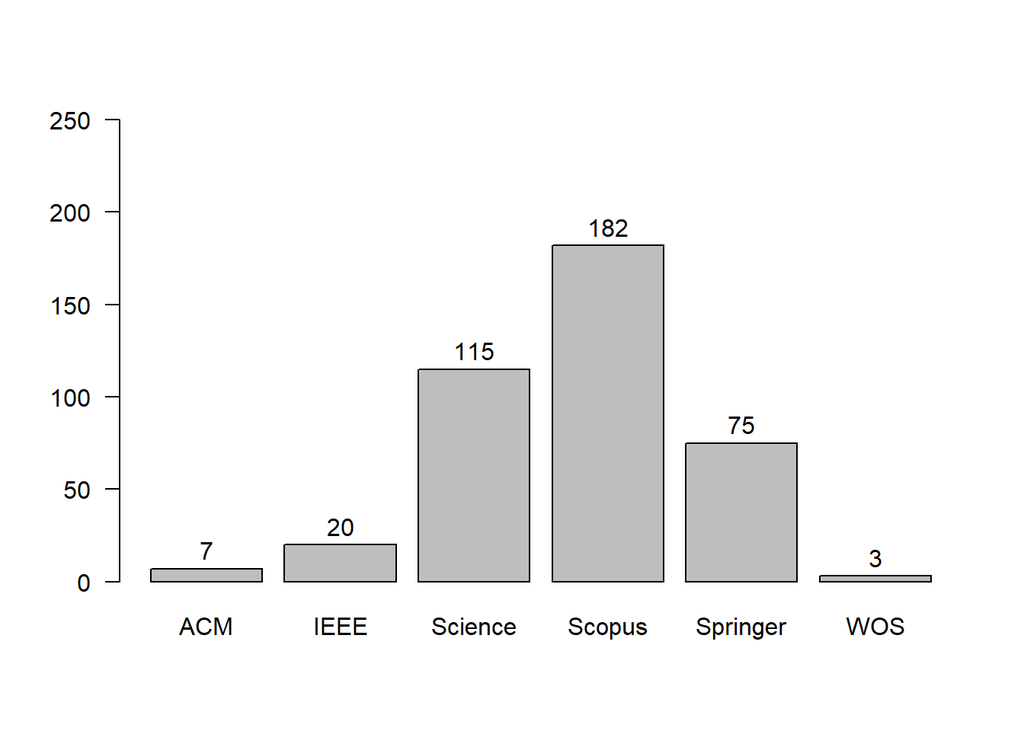

```r
names(tb)[1]='ACM'
names(tb)[2]='IEEE'
names(tb)[3]='Science'
names(tb)[4]='Scopus'
names(tb)[5]='Springer'
names(tb)[6]='WOS'
# barplot with articles by source
bb<-barplot(height = tb,ylim = c(0,250),las=1)
text(x = bb,y = tb+10,labels = tb)
```

# Articles by year

```r
#Create contigency table for source column
unique(data_articles_w_duplicates$year)
```

```
##  [1] 2018 2016 2015 2014 2008 2013 2017 2010 2009 2020 2012 2002 2019 2005 2007
## [16] 2006 2011 2003 2001 2004
```

```r
tb<-table(data_articles_w_duplicates$year)
#Change names
tb
```

```
##
## 2001 2002 2003 2004 2005 2006 2007 2008 2009 2010 2011 2012 2013 2014 2015 2016
##    2    3    2    3    4    5    6   11   17   20   21   19   22   13   27   30
## 2017 2018 2019 2020
##   32   46   62   57
```

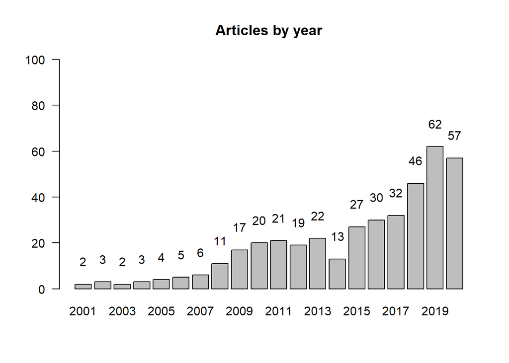

```r
# barplot with articles by year
bb<-barplot(height = tb,ylim = c(0,100),las=1, main = 'Articles by year')
text(x = bb,y = tb+10,labels = tb)
```

# Export

```r
library(xlsx)

write.xlsx(data_articles_w_duplicates,'data_articles_w_duplicates.xlsx')
```

```r
df2bib(data_articles_w_duplicates,file = 'data_articles_w_duplicates.bib')
```

# ASReview processing

Data requirements for ASReview: * title * abstract

https://asreview.readthedocs.io/en/latest/datasets.html#data-format

1. Selected randomly some articles and are identified as relevant and irrelevant, at least 5 each. [Start reviewing](https://asreview.readthedocs.io/en/latest/quicktour.html#start-reviewing);
2. ASReview orders the publications in such a way that you see the most relevant publications first, simplifying the analysis of the abstracts;
3. all articles where screened. Although the last 178 didn’t identified any relevant articles and that is possible to stop the review when [stopping criterium](https://asreview.readthedocs.io/en/latest/quicktour.html#stop-reviewing) “ASReview orders the publications in such a way that you see the most relevant publications first. In other words, there is a point where you can be confident that you have seen (almost) all publications you need, and you can stop reviewing. When to stop is left to the user. A stopping criterium could be stopping after the last X presented abstracts were labeled irrelevant, or if your time is up. You can use the chart in the statistics panel to follow your progress”

#ASReview final dataset

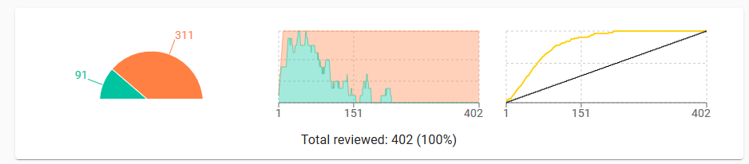

Select only select articles

```r
data_asreview <- read.xlsx2(file = "asreview/asreview_result_dropout-prediction-a-systematic-literature-review-v3_FINAL.xlsx",sheetIndex = 1,)
str(data_asreview)
```

```
## 'data.frame':    402 obs. of  13 variables:
##  $ record_id       : chr  "2" "7" "33" "34" ...
##  $ Unnamed..0      : chr  "3" "9" "35" "36" ...
##  $ category        : chr  "INPROCEEDINGS" "INPROCEEDINGS" "ARTICLE" "ARTICLE" ...
##  $ year            : chr  "2015" "2017" "2014" "2019" ...
##  $ title           : chr  "A Case Study for the Churn Prediction in Turksat Internet Service Subscription" "Churn prediction model for effective gym customer retention" "Churn prediction using comprehensible support vector machine: An analytical CRM application" "A big data analytics model for cu…
##  $ abstract        : chr  "Churn prediction is a customer relationship process that predicts for customers who are at the brink of transfe"| __truncated__ "In the fitness industry, rolling gym membership contracts allow customers to terminate a contract with little a"| __truncated__ "Support vect…
##  $ doi             : chr  "10.1145/2808797.2808821" "10.1109/BESC.2017.8256385" "https://doi.org/10.1016/j.asoc.2014.01.031" "https://doi.org/10.1016/j.ijinfomgt.2018.10.005" ...
##  $ journal         : chr  "" "" "Applied Soft Computing" "International Journal of Information Management" ...
##  $ bibtexkey       : chr  "10.1145/2808797.2808821" "8256385" "FARQUAD201431" "SHIRAZI2019238" ...
##  $ author          : chr  "G\\\"ok, Mehmet, \\\"Ozyer, Tansel, Jida, Jamal" "J, Semrl, A, Matei" "M.A.H. Farquad, Vadlamani Ravi, S. Bapi Raju" "Farid Shirazi, Mahbobeh Mohammadi" ...
##  $ source          : chr  "ACM" "IEEE" "SCIENCE" "SCIENCE" ...
##  $ final_included  : chr  "1" "1" "1" "1" ...
##  $ asreview_ranking: chr  "1" "2" "3" "4" ...
```

```r
data_asreview <- data_asreview[data_asreview$final_included==1,]

str(data_asreview)
```

```
## 'data.frame':    91 obs. of  13 variables:
##  $ record_id       : chr  "2" "7" "33" "34" ...
##  $ Unnamed..0      : chr  "3" "9" "35" "36" ...
##  $ category        : chr  "INPROCEEDINGS" "INPROCEEDINGS" "ARTICLE" "ARTICLE" ...
##  $ year            : chr  "2015" "2017" "2014" "2019" ...
##  $ title           : chr  "A Case Study for the Churn Prediction in Turksat Internet Service Subscription" "Churn prediction model for effective gym customer retention" "Churn prediction using comprehensible support vector machine: An analytical CRM application" "A big data analytics model for cu…
##  $ abstract        : chr  "Churn prediction is a customer relationship process that predicts for customers who are at the brink of transfe"| __truncated__ "In the fitness industry, rolling gym membership contracts allow customers to terminate a contract with little a"| __truncated__ "Support vect…
##  $ doi             : chr  "10.1145/2808797.2808821" "10.1109/BESC.2017.8256385" "https://doi.org/10.1016/j.asoc.2014.01.031" "https://doi.org/10.1016/j.ijinfomgt.2018.10.005" ...
##  $ journal         : chr  "" "" "Applied Soft Computing" "International Journal of Information Management" ...
##  $ bibtexkey       : chr  "10.1145/2808797.2808821" "8256385" "FARQUAD201431" "SHIRAZI2019238" ...
##  $ author          : chr  "G\\\"ok, Mehmet, \\\"Ozyer, Tansel, Jida, Jamal" "J, Semrl, A, Matei" "M.A.H. Farquad, Vadlamani Ravi, S. Bapi Raju" "Farid Shirazi, Mahbobeh Mohammadi" ...
##  $ source          : chr  "ACM" "IEEE" "SCIENCE" "SCIENCE" ...
##  $ final_included  : chr  "1" "1" "1" "1" ...
##  $ asreview_ranking: chr  "1" "2" "3" "4" ...
```

# Copy DOIs to clipboard to import to Zotero

```r
text<-as.character(data_asreview$doi)
text
```

```
##  [1] "10.1145/2808797.2808821"
##  [2] "10.1109/BESC.2017.8256385"
##  [3] "https://doi.org/10.1016/j.asoc.2014.01.031"
##  [4] "https://doi.org/10.1016/j.ijinfomgt.2018.10.005"
##  [5] "https://doi.org/10.1016/S1874-8651(09)60003-X"
##  [6] "https://doi.org/10.1016/j.eswa.2008.07.072"
##  [7] "https://doi.org/10.1016/j.intmar.2010.04.002"
##  [8] "https://doi.org/10.1016/j.dss.2016.11.007"
##  [9] "https://doi.org/10.1016/j.eswa.2011.04.007"
## [10] "https://doi.org/10.1016/j.asoc.2014.08.041"
## [11] "https://doi.org/10.1016/j.ejor.2019.03.037"
## [12] "https://doi.org/10.1016/j.neucom.2016.12.009"
## [13] "https://doi.org/10.1016/j.ins.2019.12.075"
## [14] "https://doi.org/10.1016/j.jretconser.2019.101918"
## [15] "https://doi.org/10.1016/j.eswa.2005.09.080"
```

[output cut: 76 more lines]

```r
writeClipboard(text)

length(text)
```

```
## [1] 91
```

# Final list 91 records

```r
data_asreview %>% select(title,doi) %>% distinct(title,.keep_all = TRUE) %>% arrange(title)
```

| title | doi |
| --- | --- |
| A big data analytics model for customer churn prediction in the retiree segment | https://doi.org/10.1016/j.ijinfomgt.2018.10.005 |
| A Case of Churn Prediction in Telecommunications Industry | 10.1007/978-3-319-10774-5_8 |
| A Case Study for the Churn Prediction in Turksat Internet Service Subscription | 10.1145/2808797.2808821 |
| A churn prediction model for prepaid customers in telecom using fuzzy classifiers | 10.1007/s11235-017-0310-7 |
| A comparative analysis of data preparation algorithms for customer churn prediction: A case study in the telecommunication industry | https://doi.org/10.1016/j.dss.2016.11.007 |
| A fuzzy prediction model for calling communities | 10.1504/IJNVO.2011.037162 |
| A Graph-Based Churn Prediction Model for Mobile Telecom Networks | 10.1007/978-3-642-35527-1_31 |
| A novel evolutionary data mining algorithm with applications to churn prediction | 10.1109/TEVC.2003.819264 |
| An efficient system for customer churn prediction through particle swarm optimization based feature selection model with simulated annealing | 10.1007/s10586-017-1172-1 |
| An empirical evaluation of rotation-based ensemble classifiers for customer churn prediction | https://doi.org/10.1016/j.eswa.2011.04.007 |

[output cut: 81 more lines]

# Merge ASReview selected articles with existing data for final analysis